# IODS course project

# Chapter 5: Dimensionality Reduction Techniques

```r
library("GGally")
library("dplyr")


human <- read.csv("D:/Johanna/Documents/Väitöskirja/Jatko-opinnot/Open data science/Rstudio_Git/IODS-project/data/human.csv", header=TRUE, sep= " ")

str(human)
```

```
## 'data.frame':    155 obs. of  8 variables:
##  $ eduratio: num  1.007 0.997 0.983 0.989 0.969 ...
##  $ labratio: num  0.891 0.819 0.825 0.884 0.829 ...
##  $ lifexp  : num  81.6 82.4 83 80.2 81.6 80.9 80.9 79.1 82 81.8 ...
##  $ expedu  : num  17.5 20.2 15.8 18.7 17.9 16.5 18.6 16.5 15.9 19.2 ...
##  $ gni     : int  64992 42261 56431 44025 45435 43919 39568 52947 42155 32689 ...
##  $ matmor  : int  4 6 6 5 6 7 9 28 11 8 ...
##  $ adobirth: num  7.8 12.1 1.9 5.1 6.2 3.8 8.2 31 14.5 25.3 ...
##  $ parlia  : num  39.6 30.5 28.5 38 36.9 36.9 19.9 19.4 28.2 31.4 ...
```

```r
summary(human)
```

```
##     eduratio         labratio          lifexp          expedu
##  Min.   :0.1717   Min.   :0.1857   Min.   :49.00   Min.   : 5.40
##  1st Qu.:0.7264   1st Qu.:0.5984   1st Qu.:66.30   1st Qu.:11.25
##  Median :0.9375   Median :0.7535   Median :74.20   Median :13.50
##  Mean   :0.8529   Mean   :0.7074   Mean   :71.65   Mean   :13.18
##  3rd Qu.:0.9968   3rd Qu.:0.8535   3rd Qu.:77.25   3rd Qu.:15.20
##  Max.   :1.4967   Max.   :1.0380   Max.   :83.50   Max.   :20.20
##       gni             matmor          adobirth          parlia
##  Min.   :   581   Min.   :   1.0   Min.   :  0.60   Min.   : 0.00
##  1st Qu.:  4198   1st Qu.:  11.5   1st Qu.: 12.65   1st Qu.:12.40
##  Median : 12040   Median :  49.0   Median : 33.60   Median :19.30
##  Mean   : 17628   Mean   : 149.1   Mean   : 47.16   Mean   :20.91
##  3rd Qu.: 24512   3rd Qu.: 190.0   3rd Qu.: 71.95   3rd Qu.:27.95
##  Max.   :123124   Max.   :1100.0   Max.   :204.80   Max.   :57.50
```

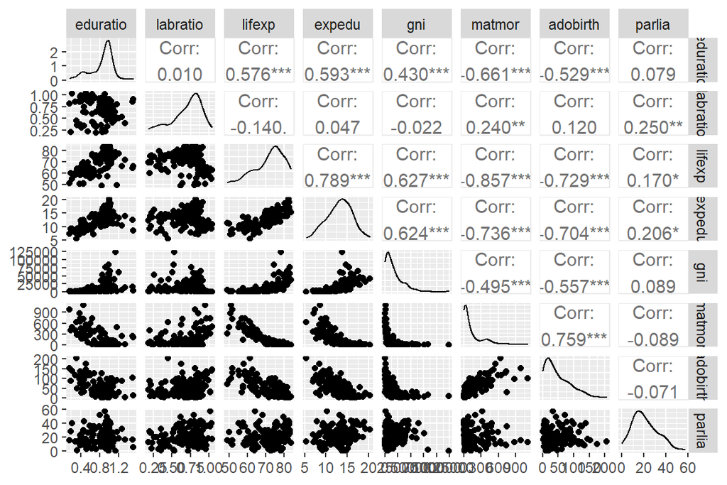

```r
ggpairs(human)
```

The human data includes 155 observations on 8 variables.

CORRELATIONS: Many of the variables correlate moderately of strongly with each other. The strongest negative correlations that are also statistically significant, are found between life expectancy (lifexp) and maternal mortality (matmor) (r = -0.86), life expectancy (lifexp) and adolescent birth rate (adobirth) (r = -0.73), maternal mortality (matmor) and expected years of education (expedu) (r = -0.74), and expected years of education (expedu) and adolescent birth rate (adobirth) (r = -0.70). The ratio of Female and Male populations with secondary education (eduratio) correlates negatively with maternal mortality (matmor) (r = -0.66) and adolescent birth rate (adobirth) (r = -0.53) and these correlations are statistically significant. Strongest statistically significant positive correlations are found between expected years of education (expedu) and life expectancy (lifexp) (r = 0.79), and adolescent birth rate (adobirth) and maternal mortality (matmor) (r = 0.76). The ratio of Female and Male populations with secondary education (eduratio) correlates positively and statistically significantly with life expectancy (lifexp) (r = 0.58), expected years of education (expedu) (r = 0.59), and Gross National Income per capita (gni) (r = 0.43). Gross National Income per capita (gni) correlates positively with life expectancy (lifexp) (r = 0.63), and expected years of education (expedu) (r = 0.62) and these correlations are statistically significant.

Next, we will run a principal component analysis on the data and draw a biplot of the results. First, we will run the PCA wihtout standardizing the data. Then, we will standardize the data and run the PCA again.

```r
#PCA with unstandardized data
#principal component analysis (with the SVD method)
pca_human <- prcomp(human)

#Summary of the results
summary(pca_human)
```

```
## Importance of components:
##                              PC1      PC2   PC3   PC4   PC5   PC6    PC7    PC8
## Standard deviation     1.854e+04 185.5219 25.19 11.45 3.766 1.566 0.1912 0.1591
## Proportion of Variance 9.999e-01   0.0001  0.00  0.00 0.000 0.000 0.0000 0.0000
## Cumulative Proportion  9.999e-01   1.0000  1.00  1.00 1.000 1.000 1.0000 1.0000
```

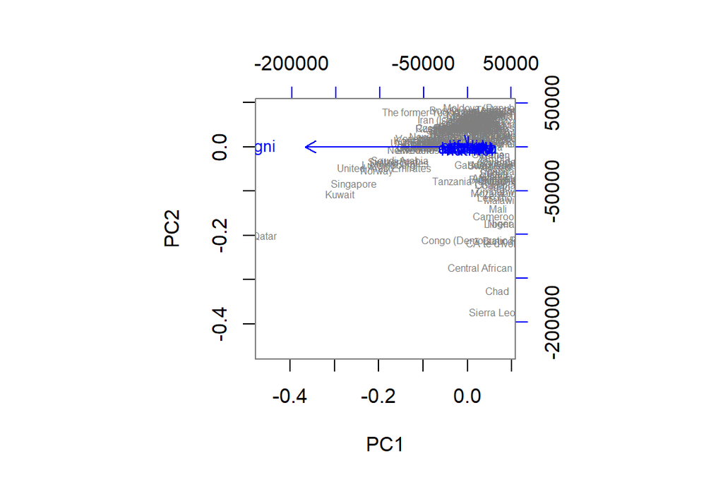

```r
# draw a biplot of the principal component representation and the original variables
biplot(pca_human, choices = 1:2, cex = c(0.5, 0.8), col = c("grey50", "blue"), caption = 'Results on principal components analysis without standardizing the data first')
```

```r
#PCA with standardized data
# standardize the variables
human_std <- scale(human)

# print out summaries of the standardized variables
summary(human_std)
```

```
##     eduratio          labratio           lifexp            expedu
##  Min.   :-2.8189   Min.   :-2.6247   Min.   :-2.7188   Min.   :-2.7378
##  1st Qu.:-0.5233   1st Qu.:-0.5484   1st Qu.:-0.6425   1st Qu.:-0.6782
##  Median : 0.3503   Median : 0.2316   Median : 0.3056   Median : 0.1140
##  Mean   : 0.0000   Mean   : 0.0000   Mean   : 0.0000   Mean   : 0.0000
##  3rd Qu.: 0.5958   3rd Qu.: 0.7350   3rd Qu.: 0.6717   3rd Qu.: 0.7126
##  Max.   : 2.6646   Max.   : 1.6632   Max.   : 1.4218   Max.   : 2.4730
##       gni              matmor           adobirth           parlia
##  Min.   :-0.9193   Min.   :-0.6992   Min.   :-1.1325   Min.   :-1.8203
##  1st Qu.:-0.7243   1st Qu.:-0.6496   1st Qu.:-0.8394   1st Qu.:-0.7409
##  Median :-0.3013   Median :-0.4726   Median :-0.3298   Median :-0.1403
##  Mean   : 0.0000   Mean   : 0.0000   Mean   : 0.0000   Mean   : 0.0000
##  3rd Qu.: 0.3712   3rd Qu.: 0.1932   3rd Qu.: 0.6030   3rd Qu.: 0.6127
##  Max.   : 5.6890   Max.   : 4.4899   Max.   : 3.8344   Max.   : 3.1850
```

```r
# perform principal component analysis (with the SVD method)
pca_human_std <- prcomp(human_std)

#Summary of the results
summary(pca_human_std)
```

```
## Importance of components:
##                           PC1    PC2     PC3     PC4     PC5     PC6     PC7
## Standard deviation     2.0708 1.1397 0.87505 0.77886 0.66196 0.53631 0.45900
## Proportion of Variance 0.5361 0.1624 0.09571 0.07583 0.05477 0.03595 0.02634
## Cumulative Proportion  0.5361 0.6984 0.79413 0.86996 0.92473 0.96069 0.98702
##                            PC8
## Standard deviation     0.32224
## Proportion of Variance 0.01298
## Cumulative Proportion  1.00000
```

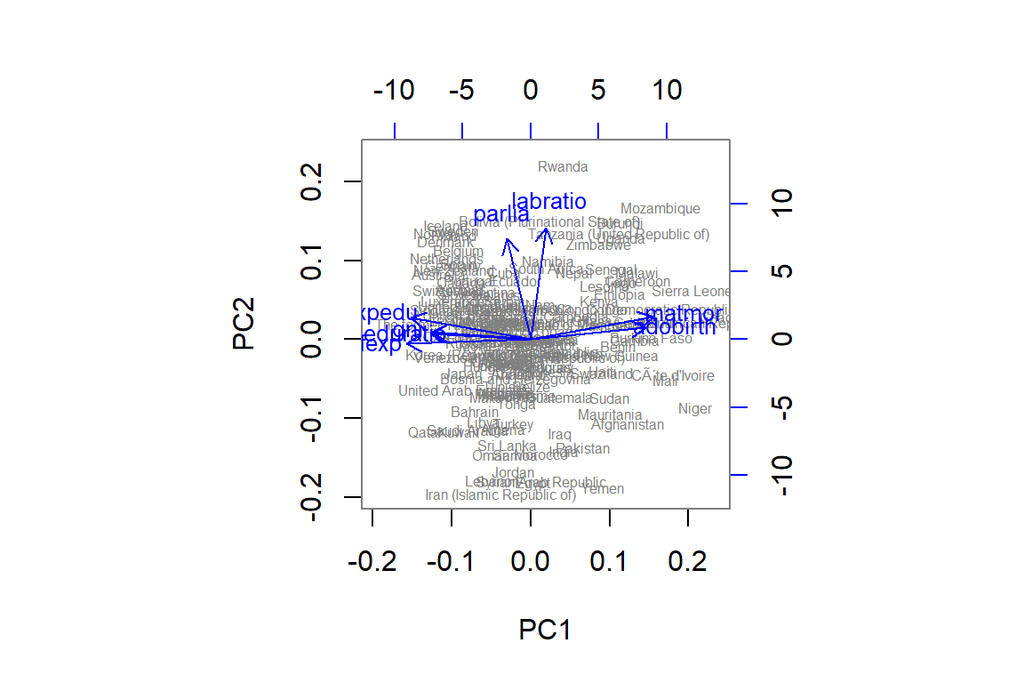

```r
# draw a biplot of the principal component representation and the original variables
biplot(pca_human_std, choices = 1:2, cex = c(0.5, 0.8), col = c("grey50", "blue"), caption = 'Results on principal components analysis with standardized data')
```

(NOTE: For some reason the “caption” argument is not working in the plots!?)

RESULTS OF THE PCA ANALYSES: The result of principal component analysis of unstandardized data is very different from the result of standardized data. The variable “gni” dominates the result of the unstandardized data, probably because it has so much larger range and variation than the other variables. The first component (PC1) explains already 99,99% of the variation in the unstandardized data, and the Gross National Income per capita (gni) seems to be the most relevant variable.

The result of standardized data has also other relevant variables that have an importance on the components. The first two components explain 53.6% (PC1) and 16.2% (PC2) of the variation in the data (together almost 70% of the variation). There are 6 variables that are relevant for the PC1 and 2 variables that are relevant for the PC2: in the high end of PC1 there are countries that have high maternal morbidity and adolescent birth rate. In the low end of PC1 there are countries that have high expected years of education, high life expectancy at birth, high Gross National Income per capita and high ratio of Female and Male populations with secondary education. In the high end of PC 2 there are countries that have high percent of representation in parliament and high ratio of labour force participation of females and males.

INTERPRETATON OF THE FIRST TWO COMPONENTS:

PC1 seems to separate rich and developed countries from poorer and less developed countries, since the variables relevant for this component are maternal morbidity, adolescent birth rate, expected years of education, life expectancy at birth, Gross National Income per capita and ratio of Female and Male populations with secondary education, so that high scores on this component reflect high maternal morbidity and adolescent birth rate, and low values on the other variables, and low scores on this component reflects high expected years of education, life expectancy at birth, Gross National Income per capita and ratio of Female and Male populations with secondary education (meaning that men and women have equally or almost equally secondary education), and low scores on the other two variables. Rich and developed countries score low on PC1 and poorer and less developed countries score higher.

PC2 seems to separate “democratic” countries from more conservative countries. In the high end of this component are countries that have equally or almost equally men and women in the labour force and the parliament represents the people of the country well. In the low end of this component are countries, in which women are not working and the parliament is not representing the people of the country that well.

MULTIPLE CORRESPONDENCE ANALYSIS ON TEA DATA

Next, we will run a multiple correspondence analysis on the tea data, which can be found from the “FactoMineR” package. First, we will load the tea data in and explore its structure.

```r
library("FactoMineR")
data(tea) #Load the tea data
dim(tea) #Dimensions
```

```
## [1] 300  36
```

```r
str(tea) #Structure
```

```
## 'data.frame':    300 obs. of  36 variables:
##  $ breakfast       : Factor w/ 2 levels "breakfast","Not.breakfast": 1 1 2 2 1 2 1 2 1 1 ...
##  $ tea.time        : Factor w/ 2 levels "Not.tea time",..: 1 1 2 1 1 1 2 2 2 1 ...
##  $ evening         : Factor w/ 2 levels "evening","Not.evening": 2 2 1 2 1 2 2 1 2 1 ...
##  $ lunch           : Factor w/ 2 levels "lunch","Not.lunch": 2 2 2 2 2 2 2 2 2 2 ...
##  $ dinner          : Factor w/ 2 levels "dinner","Not.dinner": 2 2 1 1 2 1 2 2 2 2 ...
##  $ always          : Factor w/ 2 levels "always","Not.always": 2 2 2 2 1 2 2 2 2 2 ...
##  $ home            : Factor w/ 2 levels "home","Not.home": 1 1 1 1 1 1 1 1 1 1 ...
##  $ work            : Factor w/ 2 levels "Not.work","work": 1 1 2 1 1 1 1 1 1 1 ...
##  $ tearoom         : Factor w/ 2 levels "Not.tearoom",..: 1 1 1 1 1 1 1 1 1 2 ...
##  $ friends         : Factor w/ 2 levels "friends","Not.friends": 2 2 1 2 2 2 1 2 2 2 ...
##  $ resto           : Factor w/ 2 levels "Not.resto","resto": 1 1 2 1 1 1 1 1 1 1 ...
##  $ pub             : Factor w/ 2 levels "Not.pub","pub": 1 1 1 1 1 1 1 1 1 1 ...
##  $ Tea             : Factor w/ 3 levels "black","Earl Grey",..: 1 1 2 2 2 2 2 1 2 1 ...
##  $ How             : Factor w/ 4 levels "alone","lemon",..: 1 3 1 1 1 1 1 3 3 1 ...
```

[output cut: 22 more lines]

```r
#Visualization with bar plots (because most of the variables are binary)
colnames(tea)
```

```
##  [1] "breakfast"        "tea.time"         "evening"          "lunch"
##  [5] "dinner"           "always"           "home"             "work"
##  [9] "tearoom"          "friends"          "resto"            "pub"
## [13] "Tea"              "How"              "sugar"            "how"
## [17] "where"            "price"            "age"              "sex"
## [21] "SPC"              "Sport"            "age_Q"            "frequency"
## [25] "escape.exoticism" "spirituality"     "healthy"          "diuretic"
## [29] "friendliness"     "iron.absorption"  "feminine"         "sophisticated"
## [33] "slimming"         "exciting"         "relaxing"         "effect.on.health"
```

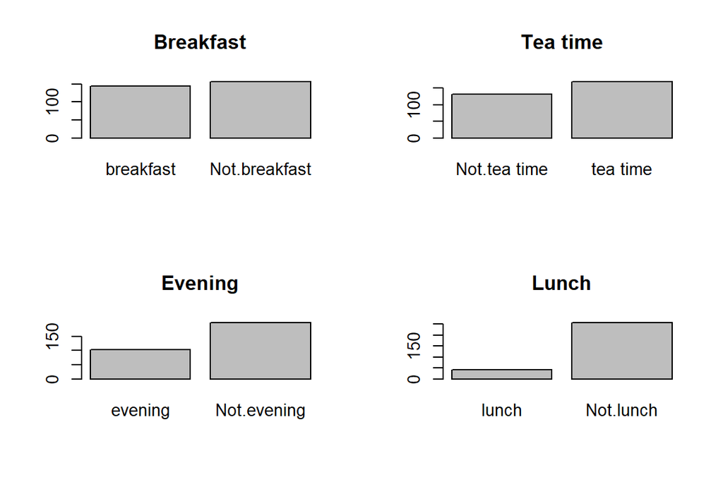

```r
counts1 <- table(tea$breakfast)
counts2 <- table(tea$tea.time)
counts3 <- table(tea$evening)
counts4 <- table(tea$lunch)
counts5 <- table(tea$dinner)
counts6 <- table(tea$always)
counts7 <- table(tea$tearoom)
counts8 <- table(tea$friends)
counts9 <- table(tea$resto)
counts10 <- table(tea$pub)
counts11 <- table(tea$Tea)
counts12 <- table(tea$How)
counts13 <- table(tea$sugar)
counts14 <- table(tea$how)
counts15 <- table(tea$where)
counts16 <- table(tea$price)
counts17 <- table(tea$age)
counts18 <- table(tea$sex)
counts19 <- table(tea$SPC)
counts20 <- table(tea$Sport)
counts21 <- table(tea$age_Q)
counts22 <- table(tea$frequency)
counts23 <- table(tea$escape.exoticism)
counts24 <- table(tea$spirituality)
counts25 <- table(tea$healthy)
counts26 <- table(tea$diuretic)
counts27 <- table(tea$friendliness)
counts28 <- table(tea$iron.absorption)
counts29 <- table(tea$feminine)
counts30 <- table(tea$sophisticated)
counts31 <- table(tea$slimming)
counts32 <- table(tea$exciting)
counts33 <- table(tea$relaxing)
counts34 <- table(tea$effect.on.health)
counts35 <- table(tea$home)
counts36 <- table(tea$work)

par(mfrow=c(2,2))
barplot(counts1, main="Breakfast")
barplot(counts2, main="Tea time")
barplot(counts3, main="Evening")
barplot(counts4, main="Lunch")
```

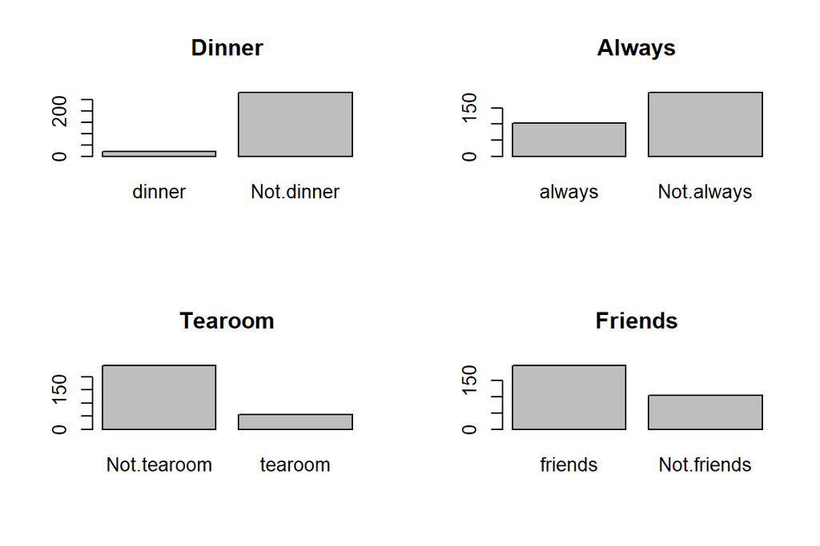

```r
barplot(counts5, main="Dinner")
barplot(counts6, main="Always")
barplot(counts7, main="Tearoom")
barplot(counts8, main="Friends")
```

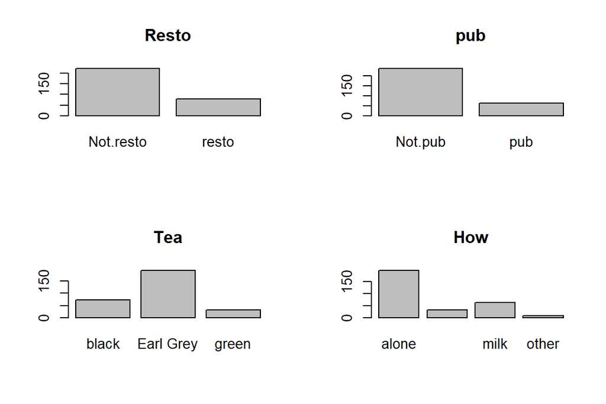

```r
barplot(counts9, main="Resto")
barplot(counts10, main="pub")
barplot(counts11, main="Tea")
barplot(counts12, main="How")
```

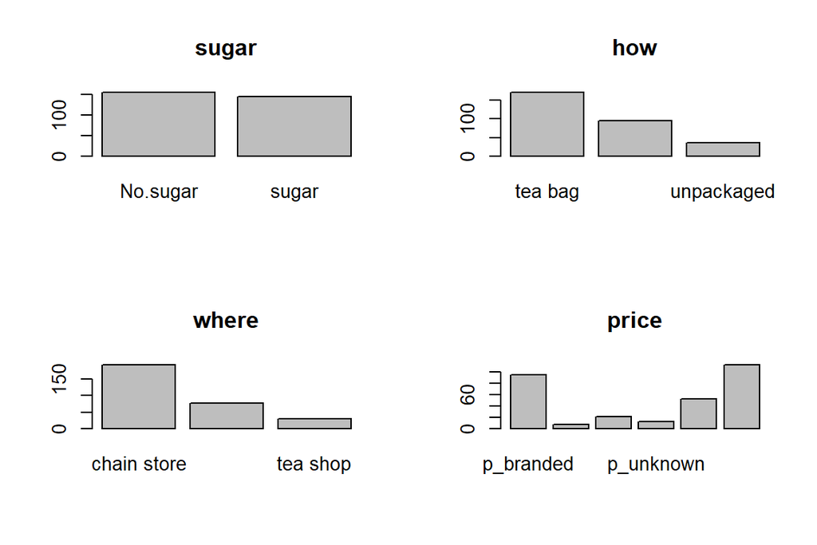

```r
barplot(counts13, main="sugar")
barplot(counts14, main="how")
barplot(counts15, main="where")
barplot(counts16, main="price")
```

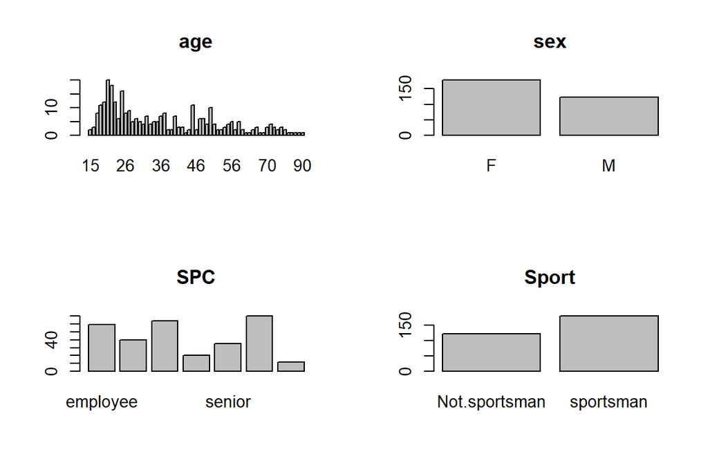

```r
barplot(counts17, main="age")
barplot(counts18, main="sex")
barplot(counts19, main="SPC")
barplot(counts20, main="Sport")
```

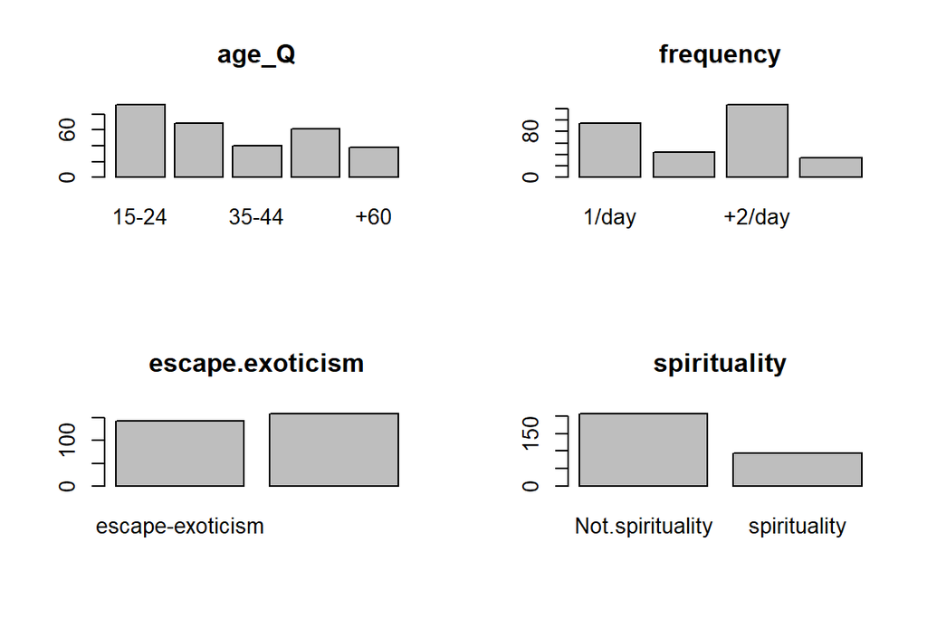

```r
barplot(counts21, main="age_Q")
barplot(counts22, main="frequency")
barplot(counts23, main="escape.exoticism")
barplot(counts24, main="spirituality")
```

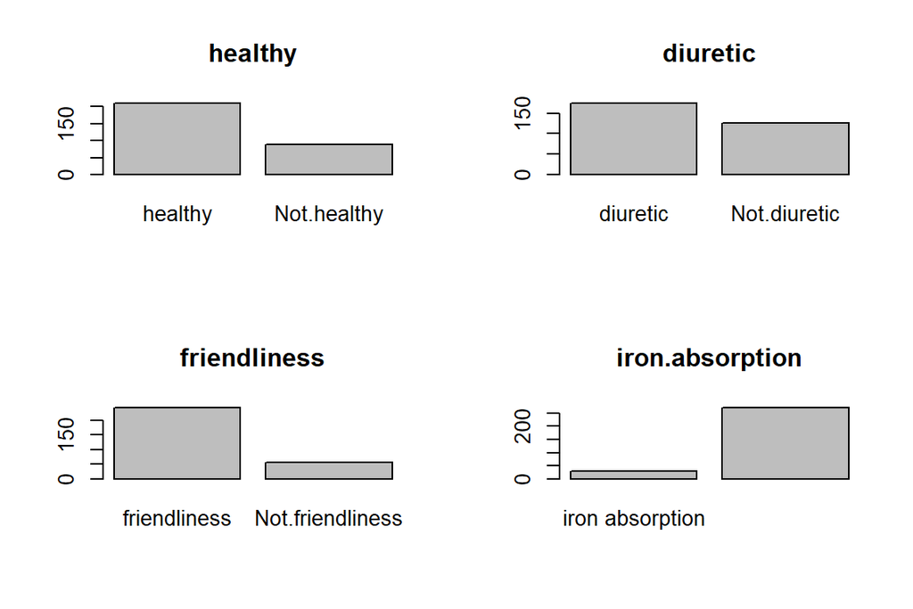

```r
barplot(counts25, main="healthy")
barplot(counts26, main="diuretic")
barplot(counts27, main="friendliness")
barplot(counts28, main="iron.absorption")
```

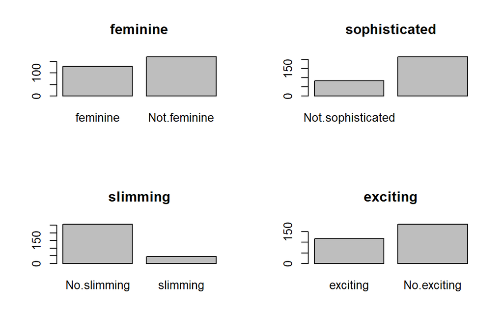

```r
barplot(counts29, main="feminine")
barplot(counts30, main="sophisticated")
barplot(counts31, main="slimming")
barplot(counts32, main="exciting")
```

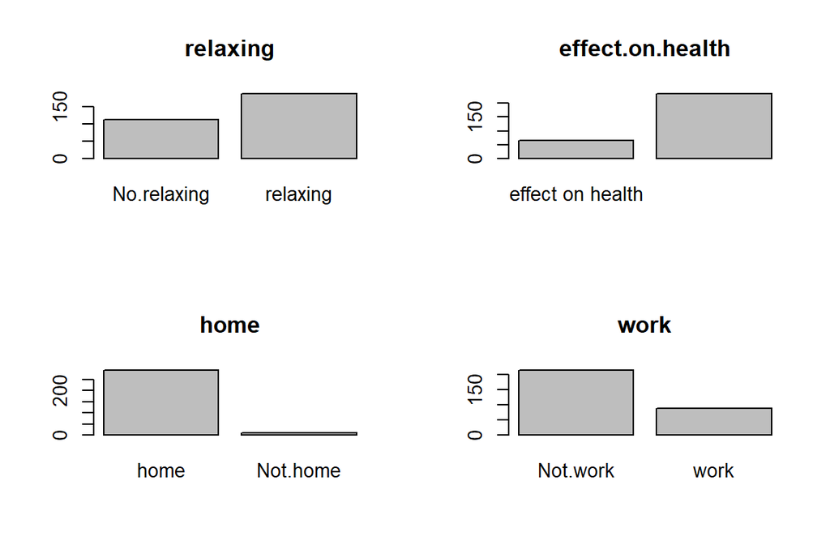

```r
barplot(counts33, main="relaxing")
barplot(counts34, main="effect.on.health")
barplot(counts35, main="home")
barplot(counts36, main="work")
```

The tea data has 300 observations on 36 variables. Most of the variables are dichotomous. Next, we will run a multiple correspondence analysis on selected columns of the data. The selected variables are: “Tea”, “How”, “how”, “sugar”, “where”, “tearoom”, “healthy”, “sophisticated”, “relaxing”.

```r
#Selecting the columns for the multiple correspondence analysis

keep_columns <- c("Tea", "How", "how", "sugar", "where", "tearoom", "healthy", "sophisticated", "relaxing")

# select the 'keep_columns' to create a new dataset
tea_time <- dplyr::select(tea, one_of(keep_columns))

# look at the structure of the data
str(tea_time)
```

```
## 'data.frame':    300 obs. of  9 variables:
##  $ Tea          : Factor w/ 3 levels "black","Earl Grey",..: 1 1 2 2 2 2 2 1 2 1 ...
##  $ How          : Factor w/ 4 levels "alone","lemon",..: 1 3 1 1 1 1 1 3 3 1 ...
##  $ how          : Factor w/ 3 levels "tea bag","tea bag+unpackaged",..: 1 1 1 1 1 1 1 1 2 2 ...
##  $ sugar        : Factor w/ 2 levels "No.sugar","sugar": 2 1 1 2 1 1 1 1 1 1 ...
##  $ where        : Factor w/ 3 levels "chain store",..: 1 1 1 1 1 1 1 1 2 2 ...
##  $ tearoom      : Factor w/ 2 levels "Not.tearoom",..: 1 1 1 1 1 1 1 1 1 2 ...
##  $ healthy      : Factor w/ 2 levels "healthy","Not.healthy": 1 1 1 1 2 1 1 1 2 1 ...
##  $ sophisticated: Factor w/ 2 levels "Not.sophisticated",..: 1 1 1 2 1 1 1 2 2 1 ...
##  $ relaxing     : Factor w/ 2 levels "No.relaxing",..: 1 1 2 2 2 2 2 2 2 2 ...
```

```r
# multiple correspondence analysis
mca <- MCA(tea_time, graph = FALSE)

# summary of the model
summary(mca)
```

```
##
## Call:
## MCA(X = tea_time, graph = FALSE)
##
##
## Eigenvalues
##                        Dim.1   Dim.2   Dim.3   Dim.4   Dim.5   Dim.6   Dim.7
## Variance               0.211   0.184   0.148   0.132   0.125   0.120   0.109
## % of var.             13.586  11.831   9.491   8.506   8.026   7.736   7.005
## Cumulative % of var.  13.586  25.417  34.908  43.414  51.440  59.176  66.181
##                        Dim.8   Dim.9  Dim.10  Dim.11  Dim.12  Dim.13  Dim.14
## Variance               0.101   0.096   0.087   0.077   0.069   0.056   0.041
## % of var.              6.516   6.175   5.567   4.927   4.405   3.582   2.646
## Cumulative % of var.  72.697  78.873  84.439  89.366  93.772  97.354 100.000
##
## Individuals (the 10 first)
##                       Dim.1    ctr   cos2    Dim.2    ctr   cos2    Dim.3
## 1                  | -0.432  0.294  0.155 | -0.004  0.000  0.000 | -0.217
## 2                  | -0.314  0.155  0.064 | -0.123  0.028  0.010 | -0.502
## 3                  | -0.489  0.377  0.301 | -0.076  0.010  0.007 | -0.231
## 4                  | -0.471  0.350  0.388 |  0.033  0.002  0.002 |  0.023
## 5                  | -0.517  0.422  0.266 | -0.009  0.000  0.000 |  0.021
## 6                  | -0.489  0.377  0.301 | -0.076  0.010  0.007 | -0.231
## 7                  | -0.489  0.377  0.301 | -0.076  0.010  0.007 | -0.231
## 8                  | -0.208  0.068  0.036 | -0.053  0.005  0.002 | -0.657
## 9                  |  0.314  0.155  0.064 | -0.440  0.350  0.126 |  0.258
## 10                 |  0.723  0.825  0.272 | -0.627  0.711  0.204 | -0.363
##                       ctr   cos2
## 1                   0.107  0.039 |
## 2                   0.568  0.163 |
## 3                   0.120  0.067 |
## 4                   0.001  0.001 |
## 5                   0.001  0.000 |
## 6                   0.120  0.067 |
## 7                   0.120  0.067 |
## 8                   0.975  0.362 |
## 9                   0.151  0.043 |
## 10                  0.298  0.069 |
##
## Categories (the 10 first)
```

[output cut: 19 more lines]

```
## tea bag             -0.220 |  -0.151   0.975   0.030  -2.990 |
## tea bag+unpackaged  -7.706 |   0.202   0.965   0.019   2.362 |
## unpackaged          11.334 |   0.186   0.313   0.005   1.188 |
##
## Categorical variables (eta2)
##                      Dim.1 Dim.2 Dim.3
## Tea                | 0.065 0.130 0.371 |
## How                | 0.118 0.189 0.344 |
## how                | 0.566 0.515 0.030 |
## sugar              | 0.076 0.004 0.310 |
## where              | 0.619 0.663 0.081 |
## tearoom            | 0.369 0.062 0.000 |
## healthy            | 0.003 0.014 0.160 |
## sophisticated      | 0.079 0.062 0.011 |
## relaxing           | 0.008 0.018 0.022 |
```

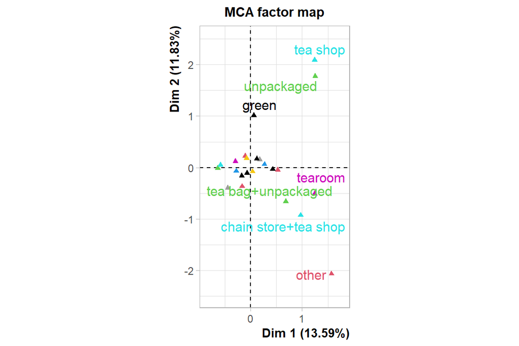

```r
# visualize MCA
plot(mca, invisible=c("ind"), habillage = "quali")
```

The multiple correspondence analysis on the selected columns of the tea data results in 14 dimensions, which together explain 100% variance of the data. The first dimension explains 13.6% of the variance and the second dimension 11.8%, and together these two dimensions explain 25.4% of the variance of the data.

The first dimension separates people on the basis of the variables: where (they buy their tea), whether or not they think drinking tea is sophisticated, how they drink their tea (with milk, or other), do they drink tea in a tearoom, and how they buy their tea (teabags or unpackaged). In the low end of dimension 1 are people, who buy their tea in tea bags from a chain store, don’t think drinking tea is sophisticated and do not use tearooms, while in the high end people at least sometimes buy their tea from a tea shop and unpackaged, use tearooms and think drinking tea is sophisticated.

The second dimension separates people on the basis of the variables: how they buy their tea (teabags or unpackaged), where (they buy their tea), which tea they like to drink, and how they drink their tea (with milk, or other). In the high end of dimension 2 are people who buy their tea unpackaged from a teashop, and who like green tea (over black or Earl grey). In the low end are people, who buy their tea from tea shop and chain store and as teabags and unpackaged, and who use “other” with their tea (over milk, lemon and sugar).

# Chapter 6: Analysis of longitudinal data

In this exercise, we are first going to analyse longitudinal data using the dataset called rats. Rats is a nutrition study conducted in three groups of rats. The three groups were on different diets and each animal’s body weight was recorded approximately weekly during a 9 week period. In the analyses, we are going to examine whether the different diets have a statistically significant effect on the rats’ weights.

First, we are going to explore the data set graphically.

```r
#First activating the libraries needed in this exercise
library(ggplot2)
library(tidyr)
library(dplyr)

#Reading the data into R in long form, and checking the dimensions and structure of the data.
ratsL <- read.table("data/ratsL.txt")
dim(ratsL)
```

```
## [1] 176   5
```

```r
str(ratsL)
```

```
## 'data.frame':    176 obs. of  5 variables:
##  $ ID    : int  1 2 3 4 5 6 7 8 9 10 ...
##  $ Group : int  1 1 1 1 1 1 1 1 2 2 ...
##  $ WD    : chr  "WD1" "WD1" "WD1" "WD1" ...
##  $ Weight: int  240 225 245 260 255 260 275 245 410 405 ...
##  $ Time  : int  1 1 1 1 1 1 1 1 1 1 ...
```

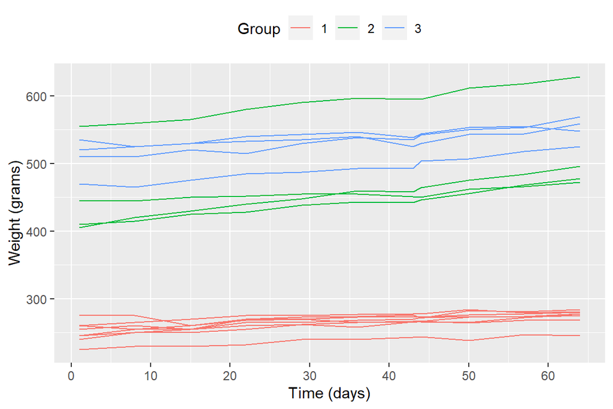

```r
#Converting categorical variables to factors (ID & Group)
ratsL$ID <- factor(ratsL$ID)
ratsL$Group <- factor(ratsL$Group)

#Drawing the first plot of the data set using unstandardized weight
ggplot(ratsL, aes(x = Time, y = Weight, group = ID)) +
  geom_line(aes(color = Group)) +
  scale_x_continuous(name = "Time (days)", breaks = seq(0, 60, 10)) +
  scale_y_continuous(name = "Weight (grams)") +
  theme(legend.position = "top")
```

In this first figure each rat is represented by one line. The colour of the line indicates the group the rat belongs to. From the plot we can see that the rats in Group 1 (red lines) are clearly lighter than rats in the other two groups. Rats in Group 2 (green lines) seems to be in the middle (expect for one rat, which is the heaviest of all), and Group 3 (blue lines) rats the heaviest. These differences in weight are present already at the baseline. Next, we will draw a similar figure with standardized weights.

```r
# Standardise the variable Weight
ratsL <- ratsL %>%
  group_by(Time) %>%
  mutate(stdweight = (Weight - mean(Weight))/sd(Weight) ) %>%
  ungroup()

# Glimpse the data
glimpse(ratsL)
```

```
## Rows: 176
## Columns: 6
## $ ID        <fct> 1, 2, 3, 4, 5, 6, 7, 8, 9, 10, 11, 12, 13, 14, 15, 16, 1, 2,~
## $ Group     <fct> 1, 1, 1, 1, 1, 1, 1, 1, 2, 2, 2, 2, 3, 3, 3, 3, 1, 1, 1, 1, ~
## $ WD        <chr> "WD1", "WD1", "WD1", "WD1", "WD1", "WD1", "WD1", "WD1", "WD1~
## $ Weight    <int> 240, 225, 245, 260, 255, 260, 275, 245, 410, 405, 445, 555, ~
## $ Time      <int> 1, 1, 1, 1, 1, 1, 1, 1, 1, 1, 1, 1, 1, 1, 1, 1, 8, 8, 8, 8, ~
## $ stdweight <dbl> -1.0011429, -1.1203857, -0.9613953, -0.8421525, -0.8819001, ~
```

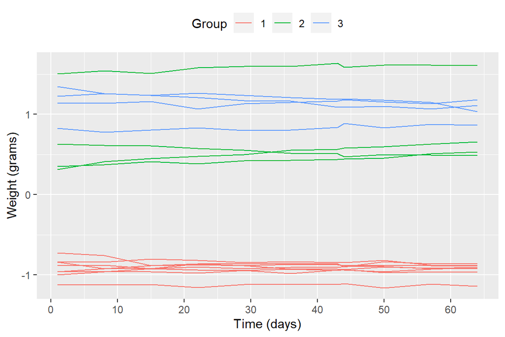

```r
#The figure again with standardized weight variables
ggplot(ratsL, aes(x = Time, y = stdweight, group = ID)) +
  geom_line(aes(color = Group)) +
  scale_x_continuous(name = "Time (days)", breaks = seq(0, 60, 10)) +
  scale_y_continuous(name = "Weight (grams)") +
  theme(legend.position = "top")
```

After standardizing the weight variable, the figure looks very similar to the first figure with unstandardized weights. The biggest difference might be that the rats’ weight does not seem to increase bytime any more, as it appeared to do in the first figure.

Next, we will draw a plot with group mean values (and standard errors).

```r
# Number of subjects (per group):
n <- 20

# Summary data with mean and standard error
ratsLS <- ratsL %>%
  group_by(Group, Time) %>%
 summarise( mean = mean(Weight), se = sd(Weight)/sqrt(n) ) %>%
  ungroup()
```

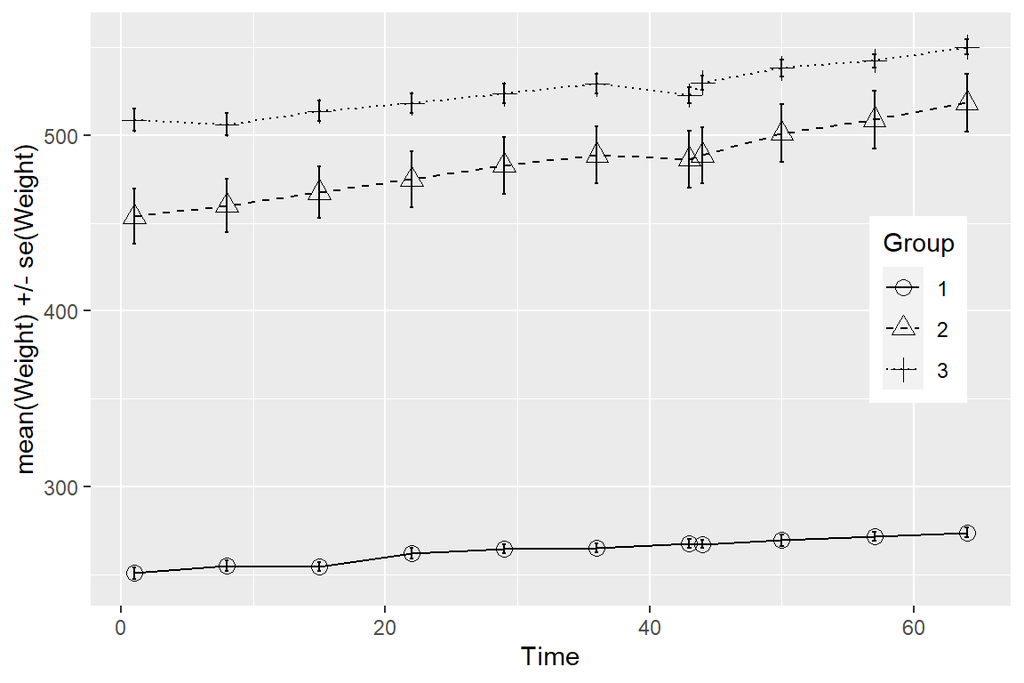

```r
# Plot the mean profiles
ggplot(ratsLS, aes(x = Time, y = mean, linetype = Group, shape = Group)) +
  geom_line() +
  scale_linetype_manual(values = c(1,2,3)) +
  geom_point(size=3) +
  scale_shape_manual(values = c(1,2,3)) +
  geom_errorbar(aes(ymin = mean - se, ymax = mean + se, linetype="1"), width=0.3) +
  theme(legend.position = c(0.9,0.5)) +
  scale_y_continuous(name = "mean(Weight) +/- se(Weight)")
```

In this figure, each of the three groups are represented by one line (which represents the mean weight of that group over time). Means and standard errors are drawn as symbols and error bars around the means in the figure. From this figure we can see that Group 1 has clearly the lightest rats. Group 2 and group 3 are more close to each other, but the rats in group 3 have higher mean weight than rats in group 2.

Next, we will draw a boxplot (in order to see whether there are outliers in the data).

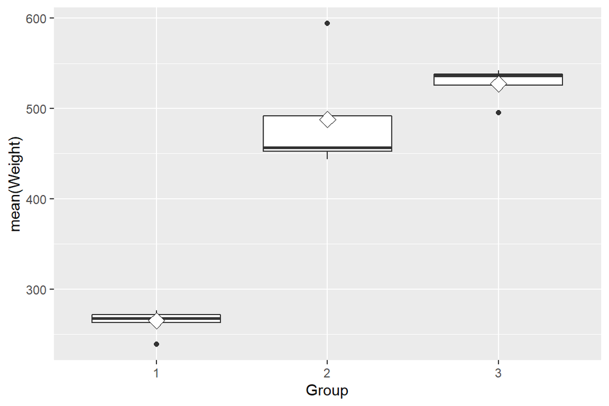

```r
#Create a boxplot

# Create a summary data by Group and subject with mean as the summary variable (ignoring baseline week 0).
ratsL8s <- ratsL %>%
  filter(Time > 1) %>%
  group_by(Group, ID) %>%
  summarise( mean=mean(Weight) ) %>%
  ungroup()
# Glimpse the data
#glimpse(ratsL8s)

# Draw a boxplot of the mean versus treatment
ggplot(ratsL8s, aes(x = Group, y = mean)) +
  geom_boxplot() +
  stat_summary(fun = "mean", geom = "point", shape=23, size=4, fill = "white") +
  scale_y_continuous(name = "mean(Weight)")
```

The three groups of rats are represented as boxes in the figure. From the boxplot we can see that there are outliers in the data. In every group, there is one outlier (Group 1 < 250 g, Group 2 > 550 g, Group 3 < 500 g). These outliers could be removed before further analysis of the data, because they might bias the conclusions made from the subsequent analysis, for example analysis of covariance. But, because the data is so limited (only 4 rats in Group 2 and Group 3), we will not remove any outliers.